# IPCW Cumulative Cost

Klaus Holst & Thomas Scheike

2026-07-29

# Overview

We describe how to perform regression modelling for cumulative cost
$$\begin{align*}
{\cal U}(t) & = \int_0^t Z(s) dN(s)
\end{align*}$$
where $N(s)$ is a counting process that registers the times at which costs are realised and accumulated, and $Z(t)$ is the cost (or mark) at the event times. The counting process can be a mix of random and fixed times, and the data are represented in counting process format with the marks/costs attached to the event times. There are many additional uses of such cumulative processes; for example, when considering time lost in a recurrent events setting, which we return to below.

We can estimate the marginal mean of the cumulative process
$$\begin{align*}
\nu(t) & = E ( {\cal U}(t) )
\end{align*}$$
possibly for strata with standard errors based on the derived influence function.

We provide semi-parametric regression modelling using the proportional model
$$\begin{align*}
E ( {\cal U}(t) | X) & = \Lambda_0(t) \exp( X^T \beta).
\end{align*}$$

In addition for a fixed time-point $t \in [0,\tau]$ we can estimate the mean given covariates
$$\begin{align*}
E ( {\cal U}(t) | X) & = \exp( X^T \beta)
\end{align*}$$
where $\tau$ is some maximum follow-up time.

- These quantities are estimated under independent right-censoring given $X$, using IPCW-adjusted estimating equations,
  - similarly to the Ghosh-Lin model for recurrent events.
- A terminal event can be specified.

We also estimate the probability of exceeding thresholds over time
$$\begin{align*}
P ( {\cal U}(t) > k ) & = \mu_k(t),
\end{align*}$$
and in the setting with a terminal event this is based on a derived competing risks data structure that keeps track of the competing terminal event.

Regression modelling of this quantity is also possible using competing risks regression models, for example via the `cifreg` function in mets.

# HF-action data

```r
library(mets)
data(hfactioncpx12)
hf <- hfactioncpx12
set.seed(1)
hf$severity <- abs((5+rnorm(741)*2))[hf$id]

## marginal mean using formula
outNZ <- recurrent_marginal(Event(entry,time,status)~strata(treatment)+cluster(id)
             +marks(severity),hf,cause=1,death.code=2)
plot(outNZ,se=TRUE)
summary(outNZ,times=3)
```

```
#> [[1]]
#>     new.time    mean        se CI-2.5% CI-97.5% strata
#> 682        3 10.3249 0.6044746  9.2056  11.5803      0
#>
#> [[2]]
#>     new.time    mean        se  CI-2.5% CI-97.5% strata
#> 601        3 9.33613 0.6429995 8.157232 10.68541      1
```

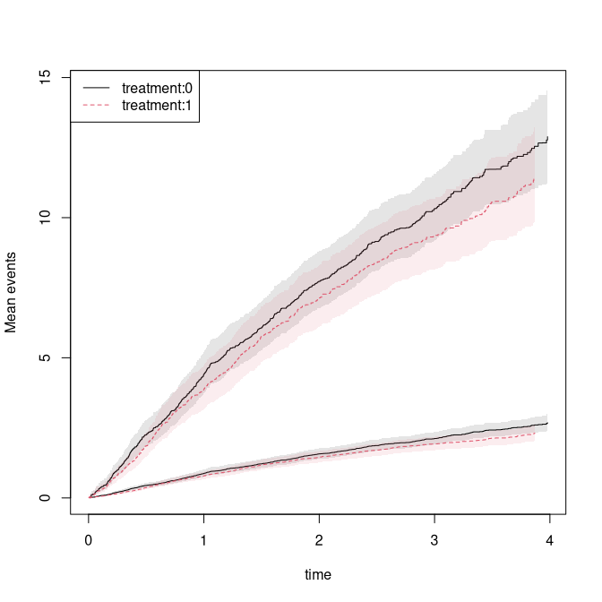

```r
outN <- recurrent_marginal(Event(entry,time,status)~strata(treatment)+cluster(id),data=hf,
               cause=1,death.code=2)
plot(outN,se=TRUE,add=TRUE)
```

```r
summary(outN,times=3)
```

```
#> [[1]]
#>     new.time     mean        se  CI-2.5% CI-97.5% strata
#> 682        3 2.118496 0.1138572 1.906692 2.353829      0
#>
#> [[2]]
#>     new.time     mean        se  CI-2.5% CI-97.5% strata
#> 601        3 1.924062 0.1216577 1.699801 2.177912      1
```

For comparison we also compute the IPCW estimates with and without marks at time 3 using the linear model, and note that they are identical. Standard errors are based on different formulae that are asymptotically equivalent, and we note that they are very similar.

```r
outNZ3 <- recregIPCW(Event(entry,time,status)~-1+treatment+cluster(id)+marks(severity),data=hf,
          cause=1,death.code=2,time=3,cens.model=~strata(treatment),model="lin")
summary(outNZ3)
```

```
#>    n events
#>  741   1281
#>
#>  741 clusters
#> coeffients:
#>            Estimate  Std.Err     2.5%    97.5% P-value
#> treatment0 10.32490  0.60444  9.14022 11.50959       0
#> treatment1  9.33613  0.64295  8.07597 10.59629       0
```

```r
head(iid(outNZ3))
```

```
#>            [,1]      [,2]
#> 1 -0.0013037837 0.0000000
#> 2  0.0089249278 0.0000000
#> 3  0.0000000000 0.0211858
#> 4 -0.0056613816 0.0000000
#> 5 -0.0005288663 0.0000000
#> 6 -0.0342554114 0.0000000
```

```r
outN3 <- recregIPCW(Event(entry,time,status)~-1+treatment+cluster(id),data=hf,cause=1,death.code=2,time=3,
         cens.model=~strata(treatment),model="lin")
summary(outN3)
```

```
#>    n events
#>  741   1281
#>
#>  741 clusters
#> coeffients:
#>            Estimate Std.Err    2.5%   97.5% P-value
#> treatment0  2.11850 0.11385 1.89535 2.34164       0
#> treatment1  1.92406 0.12165 1.68564 2.16248       0
```

```r
head(iid(outN3))
```

```
#>            [,1]        [,2]
#> 1  0.0004542472 0.000000000
#> 2  0.0009756994 0.000000000
#> 3  0.0000000000 0.009301496
#> 4 -0.0029668336 0.000000000
#> 5 -0.0001120764 0.000000000
#> 6 -0.0070693971 0.000000000
```

We also apply the semiparametric proportional cost model with IPCW adjustment:

```r
propNZ <- recreg(Event(entry,time,status)~treatment+marks(severity)+cluster(id),data=hf,cause=1,death.code=2)
summary(propNZ)
```

```
#>
#>     n events
#>  2132   1391
#>
#>  741 clusters
#> coefficients:
#>             Estimate      S.E.   dU^-1/2 P-value
#> treatment1 -0.101014  0.089005  0.024304  0.2564
#>
#> exp(coefficients):
#>            Estimate    2.5%  97.5%
#> treatment1  0.90392 0.75922 1.0762
```

```r
plot(propNZ,main="Baselines")

GL <- recreg(Event(entry,time,status)~treatment+cluster(id),hf,cause=1,death.code=2)
summary(GL)
```

```
#>
#>     n events
#>  2132   1391
#>
#>  741 clusters
#> coefficients:
#>             Estimate      S.E.   dU^-1/2 P-value
#> treatment1 -0.110404  0.078656  0.053776  0.1604
#>
#> exp(coefficients):
#>            Estimate    2.5%  97.5%
#> treatment1  0.89547 0.76754 1.0447
```

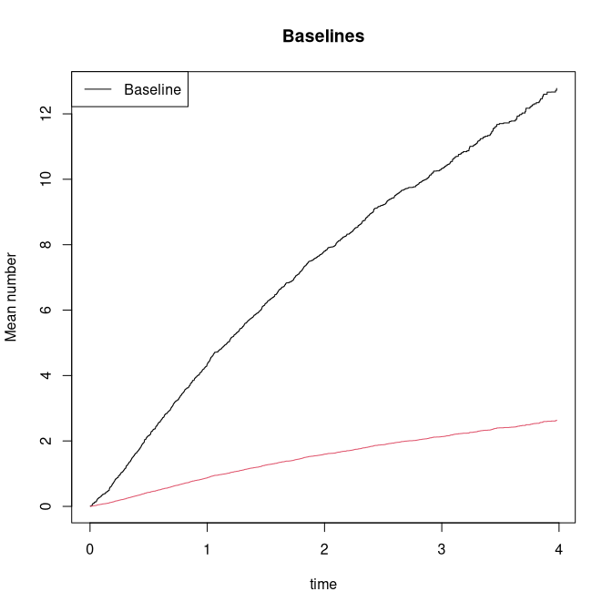

```r
plot(GL,add=TRUE,col=2)
```

# Exceed threshold

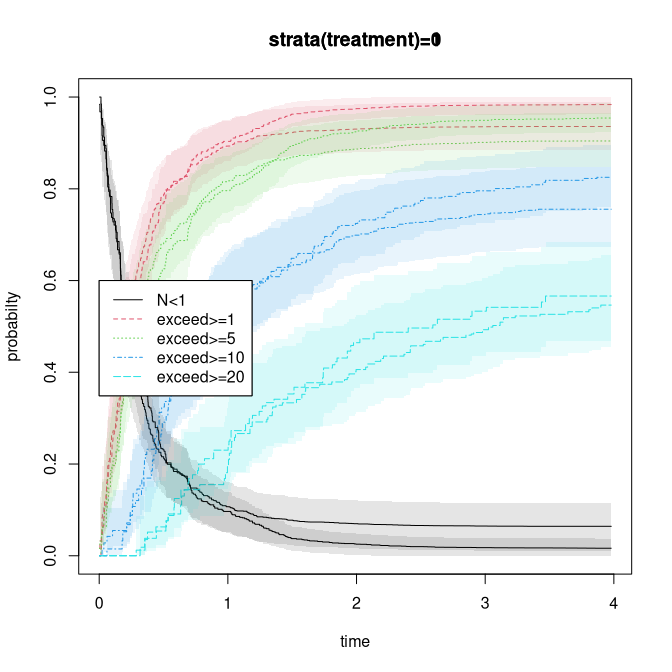

```r
ooNZ <- prob_exceed_recurrent(Event(entry,time,status)~strata(treatment)+cluster(id)+marks(severity),data=hf,
                  cause=1,death.code=2,exceed=c(1,5,10,20))
plot(ooNZ,strata=1)
plot(ooNZ,strata=2,add=TRUE)
```

```r
summary(ooNZ,times=3)
```

```
#> $`0`
#> $`0`$prob
#>            times
#>                3 2.99865085
#> N<1            3 0.06474819
#> exceed>=1      3 0.93525181
#> exceed>=5      3 0.90118229
#> exceed>=10     3 0.74537955
#> exceed>=20     3 0.49282394
#>
#> $`0`$se
#>            times
#>                3 2.99865085
#> N<1            3 0.02657120
#> exceed>=1      3 0.02657120
#> exceed>=5      3 0.03013468
#> exceed>=10     3 0.04466101
#> exceed>=20     3 0.05149605
#>
#> $`0`$lower
#>      times
#> [1,]     3 2.9986509
#> [2,]     3 0.1154033
#> [3,]     3 0.8845967
#> [4,]     3 0.8440133
#> [5,]     3 0.6627899
#> [6,]     3 0.4015580
#>
#> $`0`$upper
#>      times
#> [1,]     3 2.99865085
#> [2,]     3 0.01119234
#> [3,]     3 0.98880766
#> [4,]     3 0.96222364
#> [5,]     3 0.83826056
#> [6,]     3 0.60483284
#>
#>
#> $`1`
#> $`1`$prob
```

[output cut: 19 more lines]

```
#> [1,]     3 2.99865085
#> [2,]     3 0.03898725
#> [3,]     3 0.96101275
#> [4,]     3 0.91763959
#> [5,]     3 0.72580801
#> [6,]     3 0.43486168
#>
#> $`1`$upper
#>      times
#> [1,]     3 2.9986509
#> [2,]     3 0.0000000
#> [3,]     3 1.0000000
#> [4,]     3 0.9821470
#> [5,]     3 0.8721245
#> [6,]     3 0.6537533
```

# Cumulative time lost for recurrent events

The cumulative time lost for recurrent events is defined as
$$\begin{align*}
{\cal M}(t) = E\left[ \int_0^\tau (\tau-s) dN(s) \right] = \int_0^\tau
\mu(s) ds
\end{align*}$$
where $\mu(t) = E( N(t) )$ is the marginal mean of the recurrent events at time $t$.

```r
hf$lost5 <- 5-hf$time

RecLost <- recregIPCW(Event(entry,time,status)~-1+treatment+cluster(id)+marks(lost5),data=hf,
           cause=1,death.code=2,time=5,cens.model=~strata(treatment),model="lin")
summary(RecLost)
```

```
#>    n events
#>  741   1391
#>
#>  741 clusters
#> coeffients:
#>            Estimate Std.Err    2.5%   97.5% P-value
#> treatment0  8.58300 0.42951 7.74118 9.42482       0
#> treatment1  7.66234 0.46400 6.75292 8.57177       0
```

```r
head(iid(RecLost))
```

```
#>            [,1]       [,2]
#> 1  0.0016920221 0.00000000
#> 2  0.0073388996 0.00000000
#> 3  0.0000000000 0.02120478
#> 4 -0.0095548150 0.00000000
#> 5 -0.0005696809 0.00000000
#> 6 -0.0201750011 0.00000000
```